# Project 1: Data Wrangling, Exploration, Visualization

Raquel Mejia | rm57578

SDS322E

# Introduction

The purpose of this project was to apply data wrangling skills to two datasets with a shared identification variable, join these two datasets based on their shared identification variable, and then explore and visualize relationships within the joined dataset.

The purpose of this analysis was to examine wealth disparities across the U.S. and how these wealth disparities may influence accessibility to fertility treatments.  
I examined a [Preliminary Assisted Reproductive Technology (ART) Report from 2019](https://www.cdc.gov/art/artdata/index.html#preliminary) that was published by the Centers for Disease and Control and Prevention. This dataset contains information about fertility clinics in the U.S. that reported data on the treatment cycles that they performed in 2019, reasons for treatment, live birth and success rates, and miscellaneous clinic data, such as available treatment options and clinic location.  
The CDC describes ART as follows: *“ART includes all fertility treatments in which either eggs or embryos are handled. The main type of ART is in vitro fertilization (IVF). IVF involves extracting a woman’s eggs, fertilizing the eggs in the laboratory, and then transferring the resulting embryos.”*  
The variables analyzed from this dataset are:

1. Total number of treatment cycles performed on patients of all ages
2. Percent of embryo transfers involving at least one embryo with Pre-implantation Genetic Testing (PGT)
3. Location of each fertility clinic

The second dataset that was examined was the [U.S. Median Annual Household Income in 2019](https://www.kff.org/other/state-indicator/median-annual-income/?currentTimeframe=0&sortModel=%7B%22colId%22:%22Location%22,%22sort%22:%22asc%22%7D#notes) gathered from the U.S. Census Bureau and downloaded from the Kaiser Family Foundation website.  
The variable analyzed from this dataset includes:

1. Median annual household income from 2019

```r
library(tidyverse)
library(kableExtra)
library(knitr)
library(usmap)
library(ggpubr)
library(gridExtra)

medincome2019 <- read_csv("/stor/home/rm57578/project1/datasets/medincome2019.csv")
prelimivf2019 <- read_csv("/stor/home/rm57578/project1/datasets/prelimivf2019.csv")
```

# Joining/Merging

The 2019 Median Annual Household Income dataset, `medincome2019`, has 53 total and unique rows/observations: the median incomes of all 50 U.S. states, District of Columbia, Puerto Rico, and the median U.S household income. This dataset has two variables: location and median annual household income.

```r
n_distinct(medincome2019)
## [1] 53
nrow(medincome2019)
## [1] 53
ncol(medincome2019)
## [1] 2
```

The 2019 Prelim ART dataset, `prelimivf2019`, has 448 total and unique rows/observations, representing 448 unique fertility clinics that reported their ART data to the CDC in 2019. This dataset has 140 variables.

```r
n_distinct(prelimivf2019)
## [1] 448
nrow(prelimivf2019)
## [1] 448
ncol(prelimivf2019)
## [1] 140
```

The locations in the `medincome2019` dataset were replaced by uppercase locations (now named `joinmedincome2019`) to prepare to join with the uppercase clinic locations in the `prelimivf2019` dataset.

```r
medincome2019 %>%
  mutate(location = str_replace(Location, ".+", toupper)) %>%
  select(location, "Median Annual Household Income") -> joinmedincome2019
```

All clinic locations in the `prelimivf2019` dataset can be found as locations in the `joinmedincome2019` dataset.  
Four locations in the `joinmedincome2019` dataset are not present in the `prelimivf2019` dataset. The following locations are not listed as the current location of a fertility clinic in the `prelimivf2019` dataset: United States, Alaska, New Hampshire, and Wyoming.

```r
anti_join(prelimivf2019, joinmedincome2019, by = c("CurrentClinicState" = "location")) %>% nrow()
## [1] 0

anti_join(joinmedincome2019, prelimivf2019, by = c("location" = "CurrentClinicState"))
## # A tibble: 4 x 2
##   location      `Median Annual Household Income`
##   <chr>         <chr>
## 1 UNITED STATES $65,712
## 2 ALASKA        $75,463
## 3 NEW HAMPSHIRE $77,933
## 4 WYOMING       $65,003
```

The `prelimivf2019` and `joinmedincome2019` datasets have 49 locations in common, listed below. These 49 location are shared identification variables that will be used to join the datasets together.

```r
semi_join(joinmedincome2019, prelimivf2019, by = c("location" = "CurrentClinicState")) %>% nrow()
## [1] 49

prelimivf2019 %>%
  distinct(CurrentClinicState) %>%
  semi_join(joinmedincome2019, by = c("CurrentClinicState" = "location")) %>%
  as.list
## $CurrentClinicState
##  [1] "ALABAMA"              "ARIZONA"              "ARKANSAS"
##  [4] "CALIFORNIA"           "COLORADO"             "CONNECTICUT"
##  [7] "DELAWARE"             "DISTRICT OF COLUMBIA" "FLORIDA"
## [10] "GEORGIA"              "HAWAII"               "IDAHO"
## [13] "ILLINOIS"             "INDIANA"              "IOWA"
## [16] "KANSAS"               "KENTUCKY"             "LOUISIANA"
## [19] "MAINE"                "MARYLAND"             "MASSACHUSETTS"
## [22] "MICHIGAN"             "MINNESOTA"            "MISSISSIPPI"
## [25] "MISSOURI"             "MONTANA"              "NEBRASKA"
## [28] "NEVADA"               "NEW JERSEY"           "NEW MEXICO"
## [31] "NEW YORK"             "NORTH CAROLINA"       "NORTH DAKOTA"
## [34] "OHIO"                 "OKLAHOMA"             "OREGON"
## [37] "PENNSYLVANIA"         "PUERTO RICO"          "RHODE ISLAND"
## [40] "SOUTH CAROLINA"       "SOUTH DAKOTA"         "TENNESSEE"
## [43] "TEXAS"                "UTAH"                 "VERMONT"
## [46] "VIRGINIA"             "WASHINGTON"           "WEST VIRGINIA"
## [49] "WISCONSIN"
```

The two datasets were joined using a left join onto the `prelimivf2019` dataset. By doing so, the entire `prelimivf2019` dataset was preserved, and the median annual household incomes of the locations of fertility clinics were added as a new column to the joined dataset, `ivfincome`. A left join was performed because only the median incomes of locations that had clinics that reported ART data to the CDC in 2019 were of interest in this analysis.  
As a result of this left join, the `ivfincome` dataset has the same number of observations as the `prelimivf2019` dataset (448).

```r
left_join(prelimivf2019, joinmedincome2019, by = c("CurrentClinicState" = "location")) -> ivfincome

ivfincome %>% nrow()
## [1] 448
```

The four locations from the `joinmedincome2019` dataset that were not part of the `prelimivf2019` dataset were removed, which is helpful because there is no clinic data for these locations, so these locations would not be helpful when analyzing relationships between clinic location and income.

# Wrangling

The data wrangling below will focus on preparing and analyzing the following variables:

1. the median annual household income of the location of the fertility clinic (`Median Annual Household Income`)
2. a clinic’s total number of treatment cycles in 2019 (`TotNumCyclesAll`)
3. a location’s status as being above or below the U.S. median income (`USmedian`)
4. a clinic’s percent of embryo transfers that had at least one embryo with Pre-implantation Genetic Testing (`TransPGTAll`)

For simplicity, `CurrentClinicState` was renamed to `state`, and `Median Annual Household Income` was renamed to `medianincome`.  
In the `medianincome` column, all dollar signs and commas were removed and the incomes were re-coded as integers instead of characters.  
Some extremely small clinics had asterisks that suppressed data to preserve patient confidentiality. Rows with asterisks were removed for summary calculations.  
Additionally, the percent symbol was removed from the `TransPGTAll` variable, and it was then converted from characters to integers.

```r
ivfincome %>%
  rename("state" = "CurrentClinicState") %>%
  rename("medianincome" = "Median Annual Household Income" ) %>%
  mutate(medianincome = str_replace_all(medianincome, "[$,]*[$,]*", "")) %>%
  mutate(medianincome = as.integer(medianincome)) %>%
  mutate(TransPGTAll = na_if(TransPGTAll, "*")) %>%
  mutate(TransPGTAll = str_replace_all(TransPGTAll, "%", "")) %>%
  mutate(TransPGTAll = as.integer(TransPGTAll)) -> ivfincome
```

The number of missing observations (“NAs”) for each relevant variable are listed below. All variables have complete observations except for percent of embryo transfers with at least one PGT embryo, since some small clinics had their percentages omitted to preserve patient confidentiality.

```r
ivfincome %>%
  select(2, 5, 83, 118, 141) %>%
  summarise_all(function(x)sum(is.na(x))) %>%

  kable(digits = 0,
        col.names = c("Clinic Name",
                      "Location",
                      "Total Treatment Cycles",
                      "% Transfers with PGT",
                      "Median Income"),
        caption = "Number of Missing Observations") %>%
  kable_material(c("striped","hover"))
```

Number of Missing Observations

| Clinic Name | Location | Total Treatment Cycles | % Transfers with PGT | Median Income |
| --- | --- | --- | --- | --- |
| 0 | 0 | 0 | 16 | 0 |

The overall means and standard deviations of all clinics’ total number of treatment cycles in 2019 and all clinics’ percent of embryo transfers that had at least one embryo with PGT are listed below.

```r
ivfincome %>%
  summarise("Mean Treatment Cycles" = mean(TotNumCyclesAll),
            "SD of Treatment Cycles" = sd(TotNumCyclesAll),
            "Mean Transfers w/ at least one PGT (%)" = mean(TransPGTAll, na.rm=T),
            "SD of Transfers w/ at least one PGT (%)" = sd(TransPGTAll, na.rm=T)) %>%
  pivot_longer(1:4,
               names_to = "Summary Data of All Clinics That Reported to CDC in 2019",
               values_to = " ") %>%
  kable(digits = 0) %>%
  kable_material(c("striped", "hover"))
```

| Summary Data of All Clinics That Reported to CDC in 2019 |  |
| --- | --- |
| Mean Treatment Cycles | 738 |
| SD of Treatment Cycles | 1180 |
| Mean Transfers w/ at least one PGT (%) | 41 |
| SD of Transfers w/ at least one PGT (%) | 28 |

Fertility clinics were placed into groupings based off of their location (usually state, except for D.C. and Puerto Rico). The following summary statistics were calculated for each location:

1. Total treatment cycles performed by all fertility clinics in that location (`totalivfcycles`)
2. Median number of treatment cycles performed by all fertility clinics in that location (`medianivfcycles`)
3. Mean number of treatment cycles performed by all fertility clinics in that location (`meanivfcycles`)
4. Standard deviation of treatment cycles performed by all fertility clinics in that location (`sdivfcycles`)

This information is used later on to visualize the correlation between a location’s median income and the mean total number of treatment cycles performed by clinics in that location 2019.

```r
ivfincome %>%
  group_by(state) %>%
  summarise("totalivfcycles" = sum(TotNumCyclesAll),
            "medianivfcycles" = median(TotNumCyclesAll),
            "meanivfcycles" = mean(TotNumCyclesAll),
            "sdivfcycles" = sd(TotNumCyclesAll)) -> summarieslocations

summarieslocations %>%
  kable(digits = 0,
        col.names = c("State", "Total", "Median", "Mean", "SD")) %>%
  kable_material(c("striped", "hover")) %>%
  add_header_above(c(" " = 1, "Summaries of Total Number of Treatment Cycles"=4)) %>%
  scroll_box(height = "300px")
```

| State | Summaries of Total Number of Treatment Cycles Total | Summaries of Total Number of Treatment Cycles Median | Summaries of Total Number of Treatment Cycles Mean | Summaries of Total Number of Treatment Cycles SD |
| --- | --- | --- | --- | --- |
| ALABAMA | 1407 | 339 | 281 | 174 |
| ARIZONA | 5299 | 350 | 408 | 266 |
| ARKANSAS | 381 | 381 | 381 | NA |
| CALIFORNIA | 57491 | 405 | 798 | 1141 |
| COLORADO | 6322 | 290 | 790 | 1215 |
| CONNECTICUT | 6278 | 726 | 1046 | 756 |
| DELAWARE | 1258 | 629 | 629 | 362 |
| DISTRICT OF COLUMBIA | 1229 | 614 | 614 | 177 |
| FLORIDA | 13042 | 272 | 483 | 538 |
| GEORGIA | 6424 | 534 | 803 | 785 |
| HAWAII | 1903 | 195 | 317 | 254 |
| IDAHO | 822 | 822 | 822 | NA |
| ILLINOIS | 18410 | 558 | 767 | 854 |
| INDIANA | 3312 | 220 | 414 | 384 |
| IOWA | 1818 | 909 | 909 | 116 |
| KANSAS | 2271 | 446 | 568 | 314 |
| KENTUCKY | 764 | 179 | 191 | 125 |
| LOUISIANA | 2162 | 594 | 540 | 273 |
| MAINE | 519 | 519 | 519 | NA |
| MARYLAND | 15237 | 692 | 2540 | 4375 |
| MASSACHUSETTS | 15668 | 1130 | 1958 | 2356 |
| MICHIGAN | 6077 | 445 | 608 | 515 |
| MINNESOTA | 4294 | 911 | 859 | 441 |
| MISSISSIPPI | 496 | 184 | 165 | 48 |
| MISSOURI | 4169 | 389 | 463 | 394 |
| MONTANA | 406 | 406 | 406 | NA |
| NEBRASKA | 1483 | 742 | 742 | 332 |
| NEVADA | 2688 | 394 | 448 | 220 |
| NEW JERSEY | 15749 | 415 | 875 | 1894 |
| NEW MEXICO | 557 | 278 | 278 | 107 |
| NEW YORK | 51716 | 399 | 1203 | 2014 |
| NORTH CAROLINA | 6900 | 556 | 690 | 367 |
| NORTH DAKOTA | 313 | 313 | 313 | NA |
| OHIO | 7480 | 672 | 680 | 430 |
| OKLAHOMA | 1168 | 388 | 389 | 17 |
| OREGON | 3398 | 524 | 850 | 991 |
| PENNSYLVANIA | 9720 | 418 | 748 | 668 |
| PUERTO RICO | 319 | 46 | 106 | 110 |
| RHODE ISLAND | 862 | 862 | 862 | NA |
| SOUTH CAROLINA | 2444 | 963 | 815 | 433 |
| SOUTH DAKOTA | 380 | 380 | 380 | NA |
| TENNESSEE | 3199 | 224 | 355 | 345 |
| TEXAS | 25287 | 274 | 602 | 798 |
| UTAH | 4143 | 739 | 1036 | 1093 |
| VERMONT | 597 | 298 | 298 | 241 |
| VIRGINIA | 5103 | 491 | 464 | 378 |
| WASHINGTON | 7512 | 261 | 683 | 995 |
| WEST VIRGINIA | 247 | 124 | 124 | 95 |
| WISCONSIN | 2049 | 336 | 342 | 193 |

```r
summarieslocations %>%
  arrange(-totalivfcycles) %>%
  slice(1:3, 37:39) %>%
  kable(digits = 0,
        col.names = c("State", "Total", "Median", "Mean", "SD")) %>%
  kable_material(c("striped", "hover")) %>%
  add_header_above(c(" " = 1, "Summaries of Total Number of Treatment Cycles" = 4))
```

| State | Summaries of Total Number of Treatment Cycles Total | Summaries of Total Number of Treatment Cycles Median | Summaries of Total Number of Treatment Cycles Mean | Summaries of Total Number of Treatment Cycles SD |
| --- | --- | --- | --- | --- |
| CALIFORNIA | 57491 | 405 | 798 | 1141 |
| NEW YORK | 51716 | 399 | 1203 | 2014 |
| TEXAS | 25287 | 274 | 602 | 798 |
| RHODE ISLAND | 862 | 862 | 862 | NA |
| IDAHO | 822 | 822 | 822 | NA |
| KENTUCKY | 764 | 179 | 191 | 125 |

A new categorical variable(`USmedian`) describes whether or not a clinic is located in a state that is above or below 2019 U.S. Median Annual Household Income, $65,712. The table below counts the number of clinics in each state and categorizes each clinic by their state (including D.C. and Puerto Rico) and whether the state is above or below the median U.S. income.

```r
ivfincome %>%
  mutate("USmedian" = ifelse(medianincome>65712,
                             "Above Median U.S. Income",
                             "Below Median U.S. Income")) %>%
  group_by(state, USmedian) %>%
  summarise(countsclinics = n()) %>%
  kable(col.names = c("State", "Comparison to U.S. Median", "Number of Clinics")) %>%
  kable_material(c("striped", "hover")) %>%
  scroll_box(height = "300px")
```

| State | Comparison to U.S. Median | Number of Clinics |
| --- | --- | --- |
| ALABAMA | Below Median U.S. Income | 5 |
| ARIZONA | Below Median U.S. Income | 13 |
| ARKANSAS | Below Median U.S. Income | 1 |
| CALIFORNIA | Above Median U.S. Income | 72 |
| COLORADO | Above Median U.S. Income | 8 |
| CONNECTICUT | Above Median U.S. Income | 6 |
| DELAWARE | Above Median U.S. Income | 2 |
| DISTRICT OF COLUMBIA | Above Median U.S. Income | 2 |
| FLORIDA | Below Median U.S. Income | 27 |
| GEORGIA | Below Median U.S. Income | 8 |
| HAWAII | Above Median U.S. Income | 6 |
| IDAHO | Below Median U.S. Income | 1 |
| ILLINOIS | Above Median U.S. Income | 24 |
| INDIANA | Below Median U.S. Income | 8 |
| IOWA | Below Median U.S. Income | 2 |
| KANSAS | Below Median U.S. Income | 4 |
| KENTUCKY | Below Median U.S. Income | 4 |
| LOUISIANA | Below Median U.S. Income | 4 |
| MAINE | Below Median U.S. Income | 1 |
| MARYLAND | Above Median U.S. Income | 6 |
| MASSACHUSETTS | Above Median U.S. Income | 8 |
| MICHIGAN | Below Median U.S. Income | 10 |
| MINNESOTA | Above Median U.S. Income | 5 |
| MISSISSIPPI | Below Median U.S. Income | 3 |
| MISSOURI | Below Median U.S. Income | 9 |
| MONTANA | Below Median U.S. Income | 1 |
| NEBRASKA | Below Median U.S. Income | 2 |
| NEVADA | Below Median U.S. Income | 6 |
| NEW JERSEY | Above Median U.S. Income | 18 |
| NEW MEXICO | Below Median U.S. Income | 2 |
| NEW YORK | Above Median U.S. Income | 43 |
| NORTH CAROLINA | Below Median U.S. Income | 10 |
| NORTH DAKOTA | Below Median U.S. Income | 1 |
| OHIO | Below Median U.S. Income | 11 |
| OKLAHOMA | Below Median U.S. Income | 3 |
| OREGON | Above Median U.S. Income | 4 |
| PENNSYLVANIA | Below Median U.S. Income | 13 |
| PUERTO RICO | Below Median U.S. Income | 3 |
| RHODE ISLAND | Above Median U.S. Income | 1 |
| SOUTH CAROLINA | Below Median U.S. Income | 3 |
| SOUTH DAKOTA | Below Median U.S. Income | 1 |
| TENNESSEE | Below Median U.S. Income | 9 |
| TEXAS | Below Median U.S. Income | 42 |
| UTAH | Above Median U.S. Income | 4 |
| VERMONT | Below Median U.S. Income | 2 |
| VIRGINIA | Above Median U.S. Income | 11 |
| WASHINGTON | Above Median U.S. Income | 11 |
| WEST VIRGINIA | Below Median U.S. Income | 2 |
| WISCONSIN | Below Median U.S. Income | 6 |

```r
ivfincome %>%
  filter(medianincome > 65712) %>%
  nrow()
## [1] 231

ivfincome %>%
  filter(medianincome > 65712) %>%
  summarise(meantotalcycles = mean(TotNumCyclesAll))
## # A tibble: 1 x 1
##   meantotalcycles
##             <dbl>
## 1            938.

ivfincome %>%
  filter(medianincome < 65712) %>%
  nrow()
## [1] 217

ivfincome %>%
  filter(medianincome < 65712) %>%
  summarise(meantotalcycles = mean(TotNumCyclesAll))
## # A tibble: 1 x 1
##   meantotalcycles
##             <dbl>
## 1            526.
```

# Tidying: Reshaping

The code below reshapes a dataframe so that it can be plotted using `ggplot` aesthetics in the “Visualizing” section below.  
`Pivot_longer` was used to create a new column (`datatype`) that holds either treatment cycle data or transfer data for each state, and a second column (`yvalues`) was made to hold the corresponding values for each type of data.  
This was done to plot both sets of data on the same graph while being able to identify different data by color using `aes(x=medianincome, y = yvalues, col=datatype)`.

```r
ivfincome %>%
  group_by(state) %>%
  mutate("Number of Treatment Cycles" = mean(TotNumCyclesAll)) %>%
  mutate("% Transfers w/ at least one PGT Embryo" = mean(TransPGTAll)) %>%
  select(5, 141, 142, 143) %>%
  distinct(state, .keep_all = T) %>%
  pivot_longer(3:4, names_to = "datatype", values_to = "yvalues") -> combineplot
```

# Visualizing

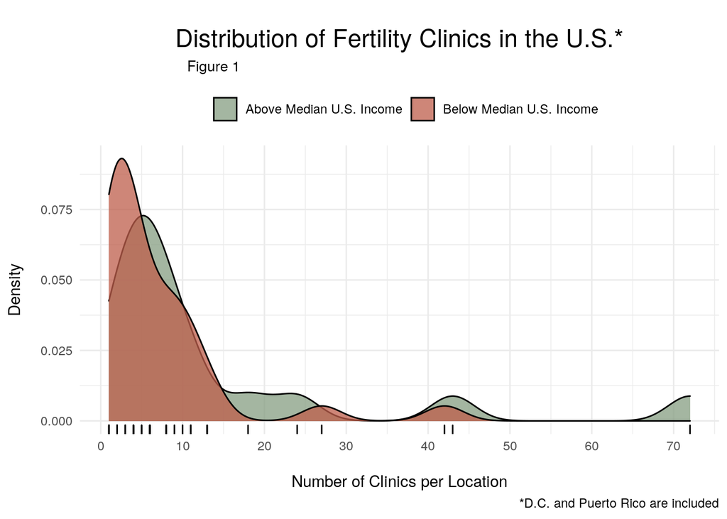

```r
ivfincome %>%
  mutate("USmedian" = ifelse(medianincome>65712,
                             "Above Median U.S. Income",
                             "Below Median U.S. Income")) %>%
  group_by(state, USmedian) %>%
  summarise(countsclinics = n()) %>%
  ggplot(aes(x=countsclinics, fill=USmedian)) +
  geom_density(alpha=0.75) +
  geom_rug() +
  theme_minimal() +
  theme(plot.title = element_text(size=17, hjust=0.5, margin=margin(15,0,0,0)),
        plot.subtitle = element_text(size=10, hjust=0.183, margin=margin(5,0,10,0)),
        axis.title.x = element_text(margin=margin(15,0,0,0)),
        axis.title.y = element_text(margin=margin(0,12,0,0)),
        legend.position = "top") +
  labs(title="Distribution of Fertility Clinics in the U.S.*",
       subtitle = "Figure 1",
       caption = "*D.C. and Puerto Rico are included",
       fill = " ") +
  scale_x_continuous(name = "Number of Clinics per Location",
                     breaks = seq(0, 100, by=10)) +
  scale_y_continuous(name = "Density",
                     labels=scales::comma,
                     breaks = seq(0, 0.125, by=0.025)) +
  scale_fill_manual(values=c("#869E81", "#BD5E4B"))
```

Figure 1 describes the distribution of fertility clinics in a particular location categorized by whether the median income of that location is above or below the U.S. median income of 2019 ($65,712). Locations that are below the U.S median income tend to have less clinics, while one location above the U.S. median income has more than 70 clinics. The overall shapes of the distributions are similar: a high frequency of locations have around 1-10 clinics, but this frequency diminishes past around 15 clinics regardless of income status.

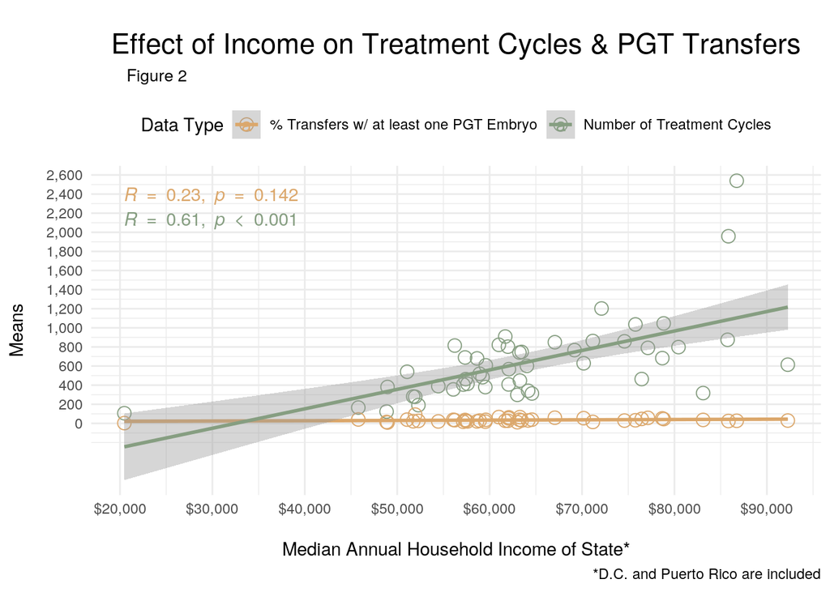

```r
combineplot %>%
  ggplot(aes(x=medianincome, y = yvalues, col=datatype)) +
  geom_point(shape=1,size=3.5) +
  geom_smooth(method = "lm") +
  stat_cor(method = "pearson", p.accuracy = 0.001)+
  theme_minimal() +
  theme(plot.title = element_text(size=17, hjust=0.5, margin=margin(15,0,0,0)),
        plot.subtitle = element_text(size=10, hjust=0.053, margin=margin(5,0,10,0)),
        axis.title.x = element_text(margin=margin(15,0,0,0)),
        axis.title.y = element_text(margin=margin(0,12,0,0)),
        legend.position = "top")+
  labs(title="Effect of Income on Treatment Cycles & PGT Transfers",
       subtitle = "Figure 2",
       caption = "*D.C. and Puerto Rico are included",
       col = "Data Type") +
  scale_x_continuous(name = "Median Annual Household Income of State*",
                     labels=scales::dollar_format(),
                     breaks = seq(20000,100000, by=10000)) +
  scale_y_continuous(name = "Means",
                     labels=scales::comma,
                     breaks = seq(0, 2600, by=200)) +
  scale_color_manual(values=c("#DBA76B", "#869E81"))
```

Figure 2 visualizes the effect of income on number of treatment cycles and percent of transfers with at least one PGT embryo.  
The green points above represent the median annual household income of a state (including D.C. and Puerto Rico) and the mean number of treatment cycles that clinics in that state performed in 2019.  
There is a moderate positive correlation between the median income of a state and the mean number of treatment cycles that clinics in that state performed (R=0.61, p < 0.001).  
The orange points above represent the median annual household income of a state (including D.C. and Puerto Rico) and the average percent of embryo transfers with at least one embryo with genetic testing that clinics in that state performed in 2019.  
There is a weak positive correlation between the median income of a state and the mean number of embryo transfers with at least one embryo with genetic testing (R=0.23, p=0.142).

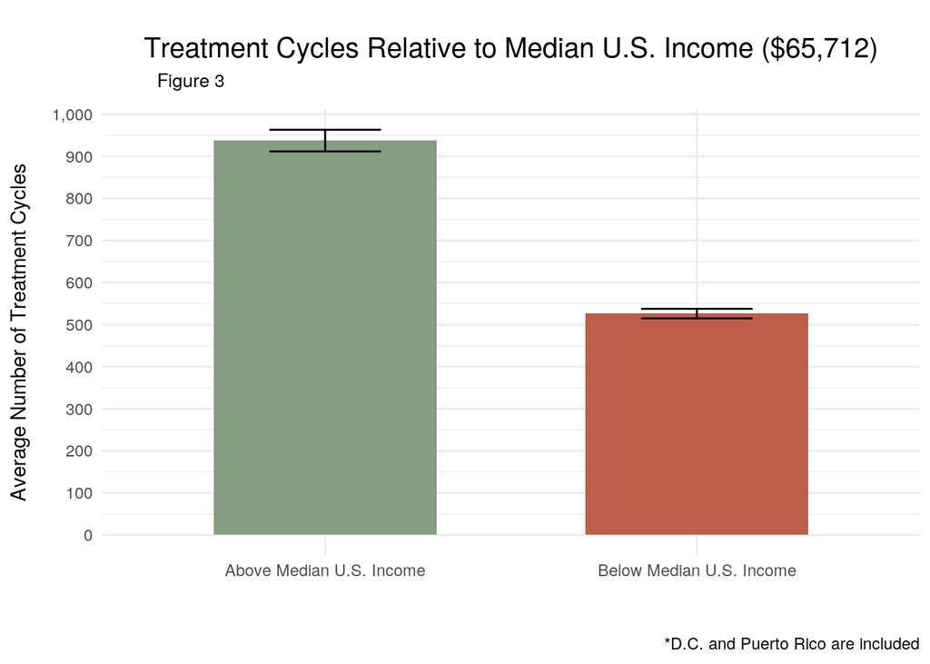

```r
ivfincome %>%
  group_by(state) %>%
  mutate("meanivfcycles" = mean(TotNumCyclesAll)) %>%
  mutate("USmedian" = ifelse(medianincome>65712,
                             "Above Median U.S. Income",
                             "Below Median U.S. Income")) %>%

  ggplot(aes(x = USmedian, y = meanivfcycles, fill=USmedian))+
  geom_bar(stat="summary",fun=mean, width=0.6)+
  geom_errorbar(stat="summary", fun.data=mean_se, width = 0.3) +
  theme_minimal() +
  theme(plot.title = element_text(size=15, hjust=0.5, margin=margin(15,0,0,0)),
        plot.subtitle = element_text(size=10, hjust=0.073, margin=margin(5,0,10,0)),
        axis.title.x = element_text(margin=margin(15,0,0,0)),
        axis.title.y = element_text(margin=margin(0,12,0,0)),
        legend.position = "none") +
  labs(title="Treatment Cycles Relative to Median U.S. Income ($65,712)",
       subtitle = "Figure 3",
       caption = "*D.C. and Puerto Rico are included") +
  xlab(" ") +
  scale_y_continuous(name = "Average Number of Treatment Cycles",
                     labels=scales::comma,
                     breaks = seq(0, 1000, by=100)) +
  scale_fill_manual(values=c("#869E81", "#BD5E4B"))
```

Figure 3 visualizes the average number of treatment cycles performed by clinics in states (including D.C. and Puerto Rico) that are above and below the median U.S. income of 2019 ($65,712). Clinics in states above the U.S. median income performed a significantly larger amount of treatment cycles than clinics in states below the U.S. median income.  
Even though there are similar numbers of clinics in locations above and below the U.S. median income (231 and 217, respectively), clinics in a location above the U.S. median income performed almost twice the number of treatment cycles on average (937 cycles, versus 526 cycles).

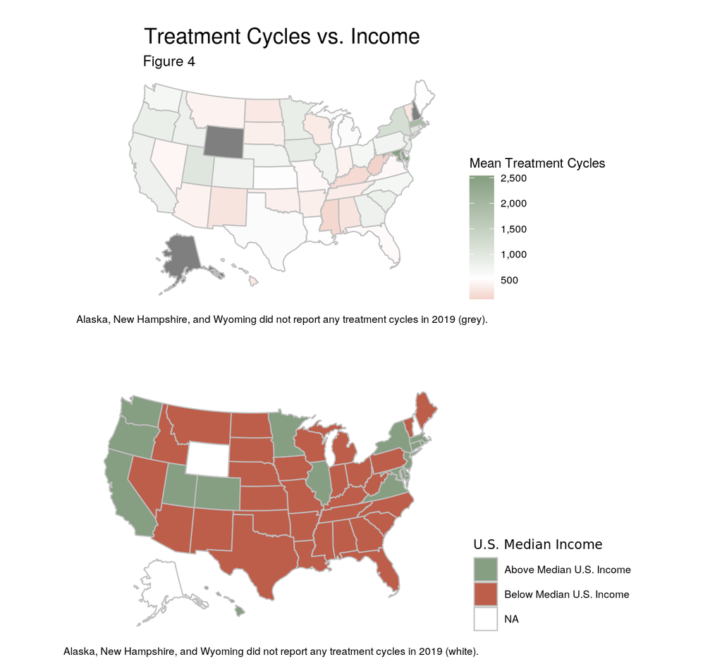

```r
#Top Map
ivfincome %>%
 group_by(state) %>%
 mutate("meanivfcycles" = mean(TotNumCyclesAll)) -> medivfincome

 plot_usmap(data = medivfincome, values = "meanivfcycles", regions = "states", col="grey") +
   labs(title = "Treatment Cycles vs. Income",
        subtitle = "Figure 4",
        caption = "Alaska, New Hampshire, and Wyoming did not report any treatment cycles in 2019 (grey).") +
   scale_fill_gradient2(low = "#9C2710", mid = "white", midpoint = 526, high = "#869E81",
                        name = "Mean Treatment Cycles",
                        label = scales::comma) +
   theme(legend.position = "right",
         plot.title = element_text(hjust = 0.5, size=15, margin=margin(15,0,0,0)),
         plot.caption = element_text(hjust = 0.5),
         plot.subtitle = element_text(size=10, hjust=0.104, margin=margin(5,0,0,0))) -> map1

#Bottom Map
ivfincome %>%
  mutate("USmedian" = ifelse(medianincome>65712,
                             "Above Median U.S. Income",
                             "Below Median U.S. Income")) %>%
  group_by(state, USmedian) -> plotUSmedian

  plot_usmap(data = plotUSmedian, values = "USmedian", regions = "states", col="grey") +
    labs(title = " ",
         caption="Alaska, New Hampshire, and Wyoming did not report any treatment cycles in 2019 (white).") +
    theme(legend.position = "right",
          plot.title = element_text(hjust = 0.5, size=15, margin=margin(15,0,0,0)),
          legend.title = element_text("Relation to U.S. Median Income"),
          plot.caption = element_text(hjust = 0.5)) +
    scale_fill_manual(values=c("#869E81", "#BD5E4B"), name = "U.S. Median Income") -> map2

#Combined figure
grid.arrange(map1, map2, ncol=1)
```

Figure 4 allows for the comparison of a state’s average number of treatment cycles and whether or not the state is above or below the median U.S. income of 2019 ($65,712).

The top map has a threshold colored in white at 526 cycles, which is the average number of treatment cycles for states below the U.S. median income. States in the top map that are red are below this threshold, while states that are green are above this threshold.

# Concluding Remarks

It appears that a state’s median income is a good predictor of the size of a clinic in that state judged by the number of treatment of cycles (Figure 2, Figure 3), but not a good predictor of the number of clinics in that state (Figure 1) or the quality of the clinic, in terms of treatment options such as PGT (Figure 2).

Additional analysis comparing number of treatment cycles, median income, and population size would be necessary to determine if an increased amount of treatment cycles is due to a higher population in that state or a higher number of patients that can afford to undergo treatments at fertility clinics.

Without looking at population data, it appears that states with higher median incomes have a higher number of treatment cycles on average, which may be an indicator that more patients are able to afford fertility treatments. Affordability is especially relevant for fertility treatment in the U.S., where according to the [National Conference of State Legislatures](https://www.ncsl.org/research/health/insurance-coverage-for-infertility-laws.aspx), “each cycle of IVF costs $12,000 to $17,000 on average”. This doesn’t include add-ons like Pre-Implantation Genetic Testing, or account for the fact that most patients may require more than one treatment cycle [(on average, patients may undergo between 3-6 treatment cycles)](https://jamanetwork.com/journals/jama/fullarticle/2478204).

Therefore the goal of this analysis was to raise awareness of wealth disparities across the U.S. and how these wealth disparities can influence accessibility to fertility treatments. Additionally, this analysis supports that infertility treatment should be covered more widely under U.S. healthcare plans in an attempt to increase the accessibility of such expensive treatments.

```
## [1] "2021-11-01 18:05:14 CDT"
```

```
##                                        sysname
##                                        "Linux"
##                                        release
##                           "4.15.0-161-generic"
##                                        version
## "#169-Ubuntu SMP Fri Oct 15 13:41:54 UTC 2021"
##                                       nodename
##                   "educcomp01.ccbb.utexas.edu"
##                                        machine
##                                       "x86_64"
##                                          login
##                                      "unknown"
##                                           user
##                                      "rm57578"
##                                 effective_user
##                                      "rm57578"
```